# zetafun

## 证明

$$ S = \dfrac{1}{1\sqrt{1}}+\dfrac{1}{2\sqrt{2}}+\dfrac{1}{3\sqrt{3}}+\cdots+\dfrac{1}{n\sqrt{n}} < 3 $$

我们可以使用积分比较审敛法来证明。

令 $S_n = \sum_{k=1}^{n} \frac{1}{k^{3/2}}$。 我们需要证明对于所有 $n \ge 1$，$S_n < 3$。

当 $n=1$ 时, $S_1 = 1 < 3$。 当 $n \ge 2$ 时, 我们可以将 $S_n$ 写作 $S_n = 1 + \sum_{k=2}^{n} \frac{1}{k^{3/2}}$。

考虑函数 $f(x) = \frac{1}{x^{3/2}}$。对于 $x > 0$，$f(x)$ 是一个正的、连续的、单调递减的函数。 因此，我们可以用积分来放缩该和式： $$ \sum_{k=2}^{n} \frac{1}{k^{3/2}} < \int_{1}^{n} \frac{1}{x^{3/2}} dx $$

计算该定积分： $$ \int_{1}^{n} x^{-3/2} dx = \left[ -2x^{-1/2} \right]_{1}^{n} = \left[ -\frac{2}{\sqrt{x}} \right]_{1}^{n} = \left(-\frac{2}{\sqrt{n}}\right) - \left(-\frac{2}{\sqrt{1}}\right) = 2 - \frac{2}{\sqrt{n}} $$

将此结果代入 $S_n$ 的不等式中： $$ S_n = 1 + \sum_{k=2}^{n} \frac{1}{k^{3/2}} < 1 + \left(2 - \frac{2}{\sqrt{n}}\right) = 3 - \frac{2}{\sqrt{n}} $$

因为对于 $n \ge 1$，$\frac{2}{\sqrt{n}} > 0$，所以 $3 - \frac{2}{\sqrt{n}} < 3$。 因此，$S_n < 3$。证毕。

```
--- Demonstration for n = 50 ---
The partial sum S_n is: 2.330940
The sum from k=2 to n is: 1.330940
The integral bound ∫[1,n] f(x)dx is: 1.717157
Is the sum from k=2 to n < integral? True

The final calculated bound (3 - 2/√n) is: 2.717157
Is S_n < 2.717157? True
Is S_n < 3? True
-----------------------------
```

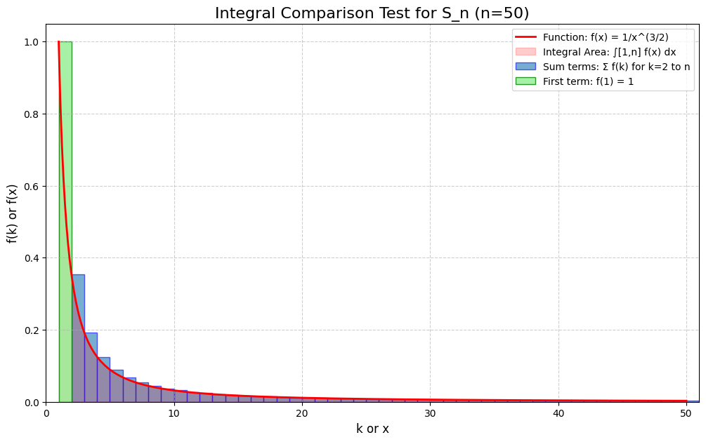

```python
import numpy as np
import matplotlib.pyplot as plt
from scipy.integrate import quad

def f(x):
    """The function 1/x^(3/2) from the proof."""
    return 1 / (x**1.5)

def calculate_partial_sum(n):
    """Calculates the partial sum S_n = Σ_{k=1 to n} 1/k^(3/2)."""
    if n < 1:
        return 0
    # Use a generator expression within sum() for a concise and efficient calculation
    return sum(f(k) for k in range(1, n + 1))

def demonstrate_inequality(n):
    """
    Calculates the sum and the bound for a given n, and prints the comparison.
    """
    print(f"--- Demonstration for n = {n} ---")

    # Calculate the partial sum S_n
    s_n = calculate_partial_sum(n)
    print(f"The partial sum S_n is: {s_n:.6f}")

    # The first term is handled separately in the proof
    first_term = 1.0
    # The rest of the sum is from k=2 to n
    sum_from_2 = s_n - first_term

    # The integral ∫[1,n] f(x) dx is the upper bound for the sum from k=2 to n
    # quad() returns the integral result and an estimated error
    integral_val, _ = quad(f, 1, n)
    print(f"The sum from k=2 to n is: {sum_from_2:.6f}")
    print(f"The integral bound ∫[1,n] f(x)dx is: {integral_val:.6f}")
    print(f"Is the sum from k=2 to n < integral? {sum_from_2 < integral_val}")

    # The final inequality from the proof
    # S_n < 1 + integral = 1 + (2 - 2/√n) = 3 - 2/√n
    final_bound = 3 - 2 / np.sqrt(n)
    print(f"\nThe final calculated bound (3 - 2/√n) is: {final_bound:.6f}")
    print(f"Is S_n < {final_bound:.6f}? {s_n < final_bound}")
    print(f"Is S_n < 3? {s_n < 3.0}")
    print("-" * (27 + len(str(n))))


def plot_comparison(n):
    """
    Generates a plot to visualize the integral comparison test.
    """
    # Set up the x-values for the rectangles (k=2, 3, ..., n)
    k_vals = np.arange(2, n + 1)

    # Set up the x-values for plotting the smooth curve f(x)
    x_curve = np.linspace(1, n, 400)
    y_curve = f(x_curve)

    plt.figure(figsize=(12, 7))

    # Plot the rectangles representing the sum from k=2 to n
    # This is a "right Riemann sum"
    plt.bar(k_vals, f(k_vals), width=1.0, alpha=0.6, label='Sum terms: Σ f(k) for k=2 to n', align='edge', edgecolor='blue')

    # Plot the function f(x)
    plt.plot(x_curve, y_curve, 'r-', linewidth=2, label='Function: f(x) = 1/x^(3/2)')

    # Fill the area under the curve to represent the integral
    plt.fill_between(x_curve, y_curve, color='red', alpha=0.2, label='Integral Area: ∫[1,n] f(x) dx')

    # Add the first term (k=1) separately for clarity
    plt.bar(1, f(1), width=1.0, alpha=0.8, label='First term: f(1) = 1', align='edge', edgecolor='green', color='lightgreen')

    plt.title(f'Integral Comparison Test for S_n (n={n})', fontsize=16)
    plt.xlabel('k or x', fontsize=12)
    plt.ylabel('f(k) or f(x)', fontsize=12)
    plt.legend()
    plt.grid(True, linestyle='--', alpha=0.6)
    plt.xlim(0, n + 1)
    plt.show()


if __name__ == '__main__':
    # Choose a value for n
    N = 50

    # Run the numerical demonstration
    demonstrate_inequality(N)

    # Show the visualization
    plot_comparison(N)
```

## 改进M的值

事实上 $S$ 函数其实是黎曼zeta函数 $\zeta(3/2)$ 的一个特例。

如果知道 $\zeta(3/2) \approx 2.612$，那么我们可以直接得出结论 $S < 3$，:-)

当然黎曼函数的计算有点复杂，通常需要使用数值方法来计算，远远要超出目前的水平了。

借助上面的将级数变为积分的思路，我们可以改变积分的起始点：

原先我们是使用 $$ \int_{1}^{n} \frac{1}{x^{3/2}} dx $$ 作为上界，现在我们可以尝试从 $k=2$ 开始积分：

$$ \int_{2}^{n} \frac{1}{x^{3/2}} dx ,$$ 那么

$$ \int_{2}^{n} \frac{1}{x^{3/2}} dx = \left[ -\frac{2}{\sqrt{x}} \right]_{2}^{n} = -\frac{2}{\sqrt{n}} + \frac{2}{\sqrt{2}} $$

可以得到更小的上界：

$$ S < 1+ \frac{1}{2\sqrt{2}}+\left(-\frac{2}{\sqrt{n}} + \frac{2}{\sqrt{2}}\right) \approx 2.7677-\frac{2}{\sqrt{n}}$$

```python
import numpy as np

def f(k):
    """The function 1/k^(3/2)"""
    return 1 / (k**1.5)

def calculate_s_m(m):
    """Calculates the partial sum S_m = Σ_{k=1 to m} f(k)"""
    return sum(f(k) for k in range(1, m + 1))

def get_tighter_bound(m):
    """
    Calculates the improved upper bound by summing the first m terms
    and adding the integral bound for the rest of the series.

    The bound is S_m + 2/√m.
    """
    if m == 0:
        # This corresponds to the original proof where we split before S_1
        # S_0 is 0, and the integral is from 1 to infinity, which is 2.
        # This gives a bound of 2, but we must add the S_1 term back, giving 3.
        # Let's start at m=1 for clarity.
        return 3.0

    s_m = calculate_s_m(m)
    integral_tail_bound = 2 / np.sqrt(m)

    return s_m + integral_tail_bound

if __name__ == '__main__':
    # The true value of the infinite sum, ζ(3/2)
    ZETA_3_2 = 2.612375348685488

    print("--- Improving the Upper Bound for S_n ---")
    print(f"True value of the infinite sum ζ(3/2) is: {ZETA_3_2:.8f}\n")

    # m=1 corresponds to the original proof in the markdown file
    # S_1 = 1. Bound = 1 + 2/√1 = 3
    print(f"m=1:  Sum first 1 term.  Bound = {get_tighter_bound(1):.8f}")

    # Let's try increasing m
    for m_val in [2, 5, 10, 50, 100]:
        bound = get_tighter_bound(m_val)
        print(f"m={m_val:<3}: Sum first {m_val:<3} terms. Bound = {bound:.8f}")
```

```
--- Improving the Upper Bound for S_n ---
True value of the infinite sum ζ(3/2) is: 2.61237535

m=1:  Sum first 1 term.  Bound = 3.00000000
m=2  : Sum first 2   terms. Bound = 2.76776695
m=5  : Sum first 5   terms. Bound = 2.65487339
m=10 : Sum first 10  terms. Bound = 2.62779203
m=50 : Sum first 50  terms. Bound = 2.61378249
m=100: Sum first 100 terms. Bound = 2.61287410
```